# MATH 216: In Class Activity 02/17

Your Name Here

# Instructions:

Answer the following questions. When you have finished, upload the `.html` file to Canvas.

# Challenge: Working with Missing Data

1. Using this vector of heights in inches, create a new vector, heights_no_na, with the NAs removed.

```r
heights <- c(63, 69, 60, 65, NA, 68, 61, 70, 61, 59, 64, 69, 63, 63, NA, 72, 65, 64, 70, 63, 65)
```

2. Calculate the median height
3. Use R to figure out how many people in the set are taller than 67 inches.

# Challenge: Working with Factors

Before this challenge you will need to import in the dataset

```r
surveys <- read.csv("https://ebmwhite.github.io/MATH0216/data/sample.csv")
```

1. Print out the names of the columns in this dataset
2. Consider the following plot of the number of participants assigned to each of the treatment groups. Use `factor()` prior to the given code to re-level the treatments so that the control group is plotted last.

```r
table(surveys$Group)
```

```
##
##    Control Treatment1 Treatment2
##         30         35         35
```

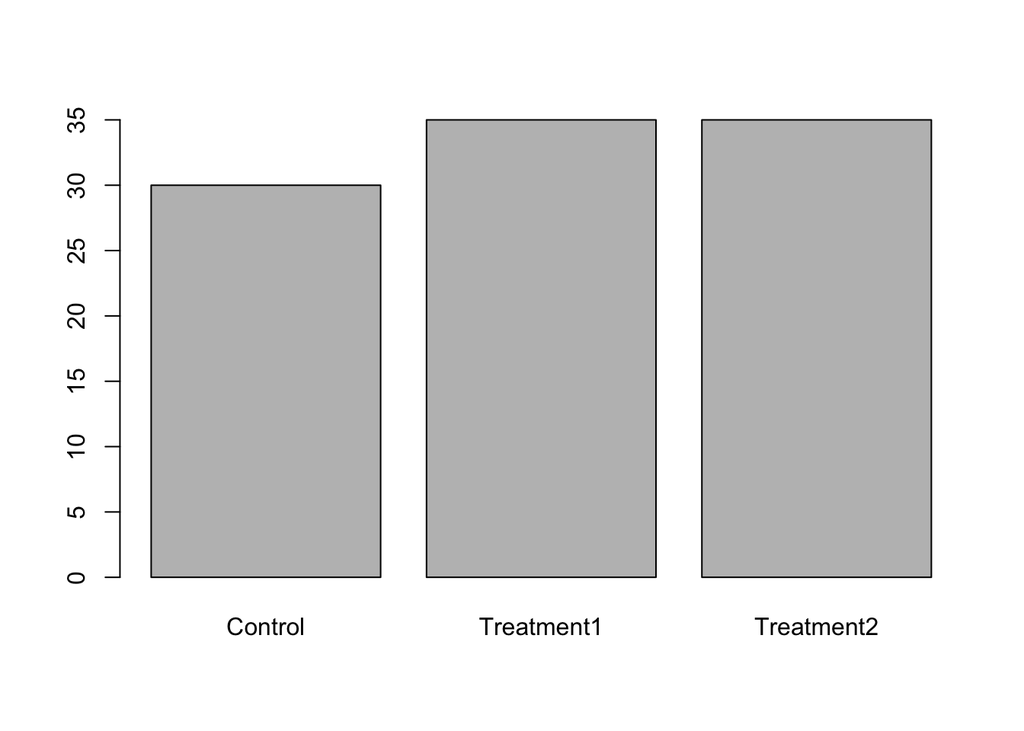

```r
barplot(table(surveys$Group))
```

Notice that the some of the genders are recorded as capital letters and some of the genders are recorded as lower case letters.

```r
levels(surveys$Gender)
```

```
## [1] "f" "F" "m" "M"
```

We can convert “F” to “f” using the following code:

```r
surveys$Gender[surveys$Gender=="F"]<-"f"
# drop levels will drop any levels which don't have any assigned to that level
# surveys$Gender <- droplevels(surveys$Gender)
```

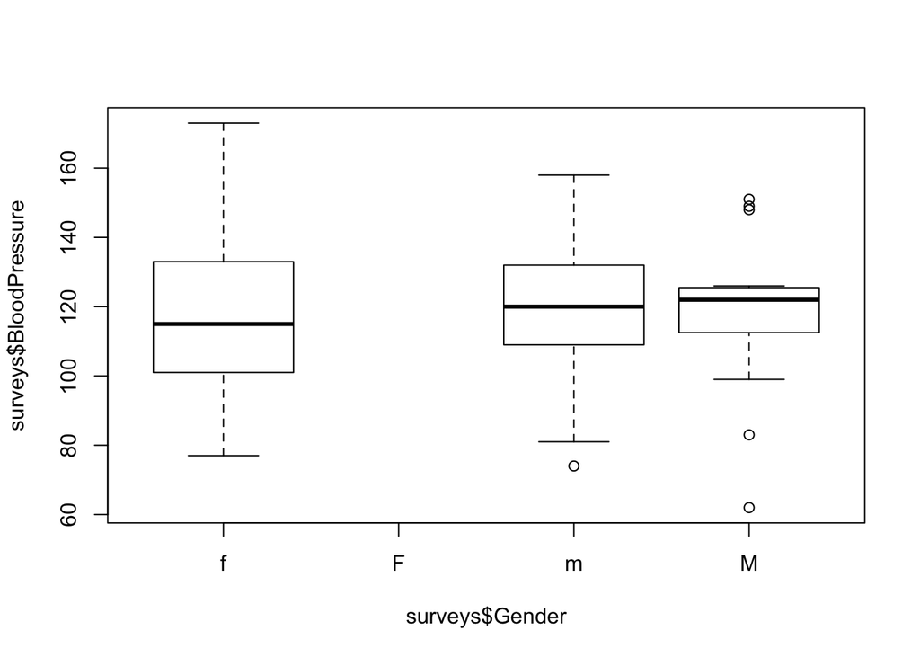

```r
boxplot(surveys$BloodPressure ~ surveys$Gender)
```

3. Create a boxplots of `BloodPressure` for `f` and `m`. Note you will need to convert `M` to `m` and then drop `M` as a factor.